# F23 Assignment 2 (10%)

## Importing the libraries

```python
import pandas as pd #To read the csv file and manage dataframes
import numpy as np #To use aggregations
import warnings #To hide the warnings
warnings.filterwarnings('ignore')
pd.set_option('display.max_columns', None)

import seaborn as sns #To create visualizations
import matplotlib.pyplot as plt #To create visualizations

from sklearn.model_selection import train_test_split #To split the dataset into train and test data
from sklearn.linear_model import LinearRegression #To fit the data into a Linear Regression model
from sklearn.metrics import mean_squared_error, r2_score #To check the mean squared error and the accuracy using r2
from sklearn.preprocessing import StandardScaler #To scale the dataset
```

## Importing the dataset

```python
HealthCareData = pd.read_csv("HealthCareDataSet - Sheet1 (1).csv") # Importing the dataset using pandas .read_csv() method
```

## Data Cleaning and Pre-processing

###### Shows the shape of the dataset

```python
HealthCareData.shape
```

```
(10999, 13)
```

###### Shows the schema of the dataset

```python
HealthCareData.info()
```

```
<class 'pandas.core.frame.DataFrame'>
RangeIndex: 10999 entries, 0 to 10998
Data columns (total 13 columns):
 #   Column                 Non-Null Count  Dtype
---  ------                 --------------  -----
 0   Id                     10999 non-null  int64
 1   LengthOfStay           10999 non-null  int64
 2   ReadmissionCount       5429 non-null   float64
 3   Gender                 10999 non-null  object
 4   FacilityId             10999 non-null  int64
 5   KidneyAilments         0 non-null      float64
 6   HeartAilments          0 non-null      float64
 7   PyschologicalAilments  10999 non-null  bool
 8   SubstanceAbuseHistory  10607 non-null  object
 9   BMI                    10997 non-null  float64
 10  ABG                    10999 non-null  float64
 11  Pulse                  10997 non-null  float64
 12  SecondaryDiagnosis     10760 non-null  float64
dtypes: bool(1), float64(7), int64(3), object(2)
memory usage: 1.0+ MB
```

###### To calculate the total null values in each column

```python
HealthCareData.isnull().sum()
```

```
Id                           0
LengthOfStay                 0
ReadmissionCount          5570
Gender                       0
FacilityId                   0
KidneyAilments           10999
HeartAilments            10999
PyschologicalAilments        0
SubstanceAbuseHistory      392
BMI                          2
ABG                          0
Pulse                        2
SecondaryDiagnosis         239
dtype: int64
```

###### Since Kidney Ailments and HeartAilments are completely null columns, we drop them

```python
HealthCareData.drop(['KidneyAilments','HeartAilments'],axis = 1,inplace = True)
```

###### Id and FacilityId can be considered as primary keys here so we drop them

```python
HealthCareData.drop(['Id','FacilityId'],axis = 1,inplace = True)
```

### Data Cleaning and Pre-processing

###### .isnull() is used to find the null values in the dataset and .sum() is used to sum the null values

```python
HealthCareData.isnull().sum()
```

```
LengthOfStay                0
ReadmissionCount         5570
Gender                      0
PyschologicalAilments       0
SubstanceAbuseHistory     392
BMI                         2
ABG                         0
Pulse                       2
SecondaryDiagnosis        239
dtype: int64
```

###### .describe() shows the aggregated summary of the column selected

```python
HealthCareData.ReadmissionCount.describe()
```

```
count    5429.000000
mean        1.883036
std         1.102079
min         1.000000
25%         1.000000
50%         2.000000
75%         2.000000
max         5.000000
Name: ReadmissionCount, dtype: float64
```

###### .value_counts() shows the distinct value in the selected column

```python
HealthCareData.ReadmissionCount.value_counts()
```

```
1.0    2701
2.0    1422
3.0     736
4.0     380
5.0     190
Name: ReadmissionCount, dtype: int64
```

###### Considering ReadmissionCount as a Categorical Variable since it is discrete and ranges between 1 and 5. if the data is categorical then we replace the null values with mode.

```python
HealthCareData['ReadmissionCount'].fillna(HealthCareData['ReadmissionCount'].mode().values[0], inplace=True)
HealthCareData.ReadmissionCount = HealthCareData.ReadmissionCount.astype('int').astype('object')
```

```python
HealthCareData.SubstanceAbuseHistory.describe()
```

```
count     10607
unique        6
top        None
freq       9080
Name: SubstanceAbuseHistory, dtype: object
```

```python
HealthCareData.SubstanceAbuseHistory.value_counts()
```

```
None       9080
Yes        1517
Some          3
Slight        3
Few           3
Unknown       1
Name: SubstanceAbuseHistory, dtype: int64
```

##### Continuing Cleaning and Pre-processing column The null values can be added in the Unknown column since it indicates that the values are unavailable The columns 'Slight', 'Few' and 'Some' can be merged together since they mean the same thing

```python
HealthCareData['SubstanceAbuseHistory'].fillna('Unknown', inplace=True)

HealthCareData['SubstanceAbuseHistory'] = HealthCareData['SubstanceAbuseHistory'].replace({'Slight': 'Some', 'Few': 'Some'})
```

```python
HealthCareData.SecondaryDiagnosis.describe()
```

```
count    10760.000000
mean         2.446933
std          1.779553
min          0.000000
25%          1.000000
50%          2.000000
75%          3.000000
max         10.000000
Name: SecondaryDiagnosis, dtype: float64
```

```python
HealthCareData.SecondaryDiagnosis.value_counts()
```

```
1.0     4196
2.0     2610
3.0     1568
4.0      946
5.0      545
6.0      363
7.0      221
8.0      133
0.0       81
9.0       59
10.0      38
Name: SecondaryDiagnosis, dtype: int64
```

```python
(HealthCareData['SecondaryDiagnosis'].isnull().sum()/HealthCareData['SecondaryDiagnosis'].sum())*100
```

```
0.9077443123551977
```

```python
HealthCareData = HealthCareData[HealthCareData['SecondaryDiagnosis'].isnull() == False]
HealthCareData.SecondaryDiagnosis = HealthCareData.SecondaryDiagnosis.astype('int').astype('object')
```

```python
HealthCareData.isnull().sum()
```

```
LengthOfStay             0
ReadmissionCount         0
Gender                   0
PyschologicalAilments    0
SubstanceAbuseHistory    0
BMI                      1
ABG                      0
Pulse                    1
SecondaryDiagnosis       0
dtype: int64
```

###### BMI is a numerical value, so we first check if it is skewed or not. We check for the skewness so that we can accordingly replace the null values with either mean or median or if the missing is data is small then we remove it entirely

```python
HealthCareData.BMI.describe()
```

```
count    10759.000000
mean        29.061298
std          2.004916
min         19.800000
25%         27.700000
50%         29.000000
75%         30.400000
max         36.700000
Name: BMI, dtype: float64
```

```python
(HealthCareData.BMI.isnull().sum()/HealthCareData.BMI.sum())*100
```

```
0.0003198255032054511
```

###### Therefore we can decide to remove the null values entirely

```python
HealthCareData = HealthCareData[HealthCareData['BMI'].isnull() == False]
HealthCareData.isnull().sum()
```

```
LengthOfStay             0
ReadmissionCount         0
Gender                   0
PyschologicalAilments    0
SubstanceAbuseHistory    0
BMI                      0
ABG                      0
Pulse                    0
SecondaryDiagnosis       0
dtype: int64
```

### Handling the Outliers

###### Handling the Outliers in BMI. We first plot a boxplot to visualize the outliers.

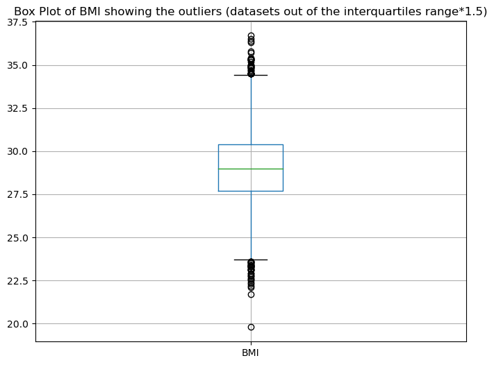

```python
BMI = 'BMI showing the outliers (datasets out of the interquartiles range*1.5)'
plt.figure(figsize=(8, 6))
HealthCareData.boxplot(column='BMI')
plt.title(f'Box Plot of {BMI}')
plt.show()
```

###### We then create Quartile1_BMI (First Quartile) and Quartile3_BMI (Third Quartile). Then we calculate the Inter Quartile Range

```python
Quartile1_BMI = HealthCareData['BMI'].quantile(0.25)
Quartile3_BMI = HealthCareData['BMI'].quantile(0.75)
IQR_BMI = Quartile3_BMI - Quartile1_BMI
```

###### Further, we calculate the lower bound and upper bound for the same

```python
lower_bound_BMI = Quartile1_BMI - 1.5 * IQR_BMI
upper_bound_BMI = Quartile3_BMI + 1.5 * IQR_BMI
```

###### After calculating the lower and upper bounds, we find the outliers which are the datapoints outside the bounds.

```python
BMI_Outliers = HealthCareData[(HealthCareData['BMI'] < lower_bound_BMI) | (HealthCareData['BMI'] > upper_bound_BMI)]
```

###### To deal with outliers we can use the methods:

1) Cutting: The extreme numbers that you identify as outliers should be eliminated or truncated. Take care not to erase too much information.

2) Elaboration: Substitute more typical values for outliers. To achieve this, you can swap them out for the mean, median, or another quantitatively determined value.

###### We unanimously decided to use Imputation to deal with the outliers. We used median to replace all the outliers in each numerical data.

```python
# Remove BMI Outliers
median_BMI = HealthCareData['BMI'].median()
HealthCareData['BMI'][(HealthCareData['BMI'] < lower_bound_BMI) | (HealthCareData['BMI'] > upper_bound_BMI)] = median_BMI
```

###### Calculating outliers for Pulse

```python
HealthCareData.Pulse.describe()
```

```
count    10759.000000
mean        77.749419
std         18.159736
min         10.000000
25%         65.000000
50%         78.000000
75%         90.000000
max        148.000000
Name: Pulse, dtype: float64
```

###### Creating boxplot for Pulse and calculating and replacing the outliers for the same.

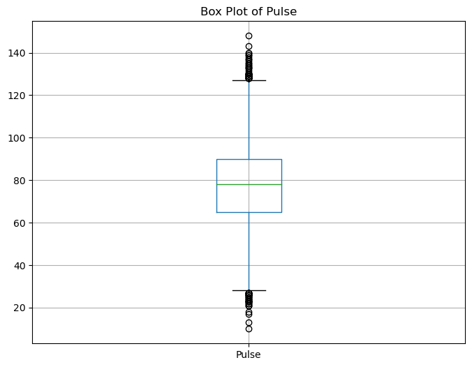

```python
Pulse = 'Pulse'
plt.figure(figsize=(8, 6))
HealthCareData.boxplot(column='Pulse')
plt.title(f'Box Plot of {Pulse}')
plt.show()


Q1_P = HealthCareData['Pulse'].quantile(0.25)
Q3_P = HealthCareData['Pulse'].quantile(0.75)
IQR_P = Q3_P - Q1_P
lower_bound_P = Q1_P - 1.5 * IQR_P
upper_bound_P = Q3_P + 1.5 * IQR_P
outliers_P = HealthCareData[(HealthCareData['Pulse'] < lower_bound_P) | (HealthCareData['Pulse'] > upper_bound_P)]
```

```python
# Remove Pulse Outliers
median_P = HealthCareData['Pulse'].median()
HealthCareData['Pulse'][(HealthCareData['Pulse'] < lower_bound_P) | (HealthCareData['Pulse'] > upper_bound_P)] = median_P
```

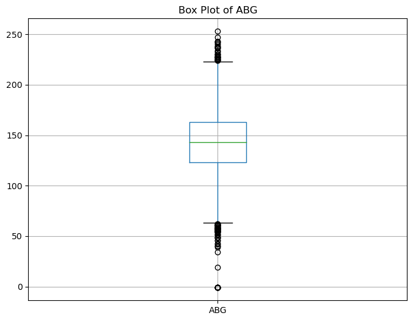

```python
ABG ='ABG'

plt.figure(figsize=(8, 6))
HealthCareData.boxplot(column='ABG')
plt.title(f'Box Plot of {ABG}')
plt.show()
```

```python
Q1_A = HealthCareData['ABG'].quantile(0.25)
Q3_A = HealthCareData['ABG'].quantile(0.75)
IQR_A = Q3_A - Q1_A
lower_bound_A = Q1_A - 1.5 * IQR_A
upper_bound_A = Q3_A + 1.5 * IQR_A
outliers_A = HealthCareData[(HealthCareData['ABG'] < lower_bound_A) | (HealthCareData['ABG'] > upper_bound_A)]
```

```python
# Remove ABG Outliers
median_ABG = HealthCareData['ABG'].median()
HealthCareData['ABG'][(HealthCareData['ABG'] < lower_bound_A) | (HealthCareData['ABG'] > upper_bound_A)] = median_ABG
```

## Exploratory Data Analysis and Visualization

#### Analysis of univariate and bivariate data

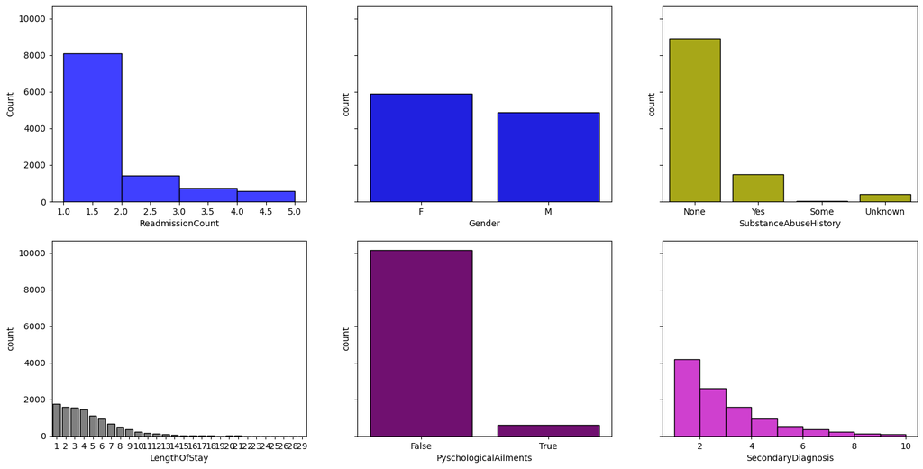

```python
figure, ax = plt.subplots(2,3,figsize=(18,9),sharey = True)

edge = [1, 2, 3, 4, 5]
ax[0,0].set_title('',fontsize = 10)
sns.histplot(x = 'ReadmissionCount', data = HealthCareData,ax = ax[0,0],color = 'b',edgecolor='black',bins=edge)

ax[1,1].set_title('',fontsize = 10)
sns.countplot(x = 'Gender', data = HealthCareData,ax = ax[0,1],color = 'b',edgecolor='black')

ax[1,0].set_title('',fontsize = 10)
sns.countplot(x = 'SubstanceAbuseHistory', data = HealthCareData,ax = ax[0,2],color = 'y',edgecolor='black')

ax[1,0].set_title('',fontsize = 10)
sns.countplot(x = 'LengthOfStay', data = HealthCareData,ax = ax[1,0],color='grey',edgecolor='black')

ax[1,1].set_title('',fontsize = 10)
sns.countplot(x = 'PyschologicalAilments', data = HealthCareData,ax = ax[1,1],color='purple',edgecolor='black')

ax[1,2].set_title('',fontsize = 10)
edges_1 = [1,2,3,4,5,6,7,8,9,10]
sns.histplot(x = 'SecondaryDiagnosis', data = HealthCareData,ax = ax[1,2],color='m',bins=edges_1,edgecolor='black')

plt.show()
```

###### ReadmissionCount:

1. Hightest frquency is shown for ReadmissionCount more than 8000 (>75% of total population), which indicates that a majority of people were re-admitted.
2. Reasons of readmission once could be due to:  
   (1) Unresolved medical conditions or complications: A patient's initial health issue might not always be totally resolved during their initial hospital stay. This may require a readmission for additional care and supervision.  
   (2) Poor post-discharge care: Poor follow-up care or disregard for recommended drugs and treatment regimens can cause a patient's condition to worsen, necessitating readmission.

###### SubstanceAbuseHistory: SubstanceAbuseHistory population data is divided into 4 samples

1. None: None data population have highest frequency
2. Yes: Yes data population have greater frequency than unknown
3. Some: Some data population have negligible frequency
4. Unkown: Unkown data population have less frequency than yes

###### LengthOfStay:A patient's duration of stay in the hospital may be prolonged for a variety of reasons. Some of these causes are as follows:

1. Lengthofstay is approx 2000 for patience who length of stay is 1 day
2. Count frequency reduce slowly from 2 lengthofstay
3. Illness Severity: Patients with more severe or complicated medical issues sometimes require lengthier hospital stays.
4. Complications: Complications that arise during therapy might result in a longer stay. Complications might include infections, severe drug responses.

###### PyschologicalAilments: These could be defined as Mental Health disorders. Some psychological ailments include these observations:

1. More than 90% of the population stated False for Psychological Ailments.
2. About 5% state yes for the same. Reasons could be due to depression, anxiety disorders, bipolar disorder, etc.

###### SecondaryDiagnosis:

1. The highest frequency can be observed in the first bin with the value of 4196.
2. There can be seen 11 unique values in total.
3. Some secondary diagnoses may signify a higher degree of medical complexity, necessitating a longer hospital stay for thorough care. Some secondary diseases could call for prolonged recuperation times, lengthening the hospital stay.

```python
HealthCareData.PyschologicalAilments.describe()
```

```
count     10759
unique        2
top       False
freq      10163
Name: PyschologicalAilments, dtype: object
```

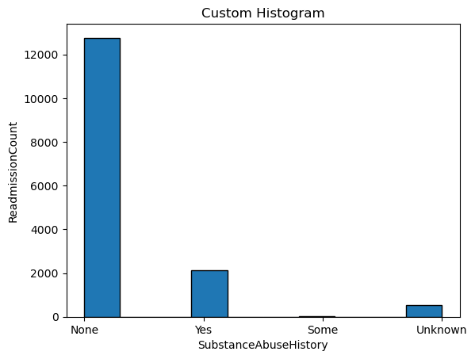

```python
plt.hist(HealthCareData['SubstanceAbuseHistory'],weights = HealthCareData['ReadmissionCount'],edgecolor = 'black')
plt.title("Custom Histogram")
plt.xlabel("SubstanceAbuseHistory")
plt.ylabel("ReadmissionCount")
plt.show()
```

[figure not shown]

```python
plt.hist(
         HealthCareData['ABG'],\
         weights = HealthCareData['LengthOfStay'],\
         edgecolor = 'black'
        )

plt.title("Custom Histogram")
plt.xlabel("LengthOfStay")
plt.ylabel("ABG")
plt.show()
```

[figure not shown]

```python
plt.hist(
         HealthCareData['BMI'],\
         weights = HealthCareData['LengthOfStay'],\
         edgecolor = 'black'
        )

plt.title("Custom Histogram")
plt.xlabel("LengthOfStay")
plt.ylabel("BMI")
plt.show()
```

[figure not shown]

```python
plt.hist(
         HealthCareData['Pulse'],\
         weights = HealthCareData['LengthOfStay'],\
         edgecolor = 'black'
        )

plt.title("Custom Histogram")
plt.xlabel("LengthOfStay")
plt.ylabel("Pulse")
plt.show()
```

###### In many clinical conditions, the duration of stay in a hospital and a patient's pulse rate might be associated. The rate of your pulse in beats per minute (bpm).

###### Several factors can alter the association between duration of stay and pulse rate:

1. Patients hospitalized with acute cardiovascular disorders, such as heart attacks, may have an increased or erratic pulse rate.
2. Post-Surgical Care: Following some procedures, particularly those involving the heart or major blood arteries, patients are continuously watched for symptoms of problems, such as irregular pulse rates.

#### Correlation plot to check for Multicollinearity and Identify the ideal features required to create the model on

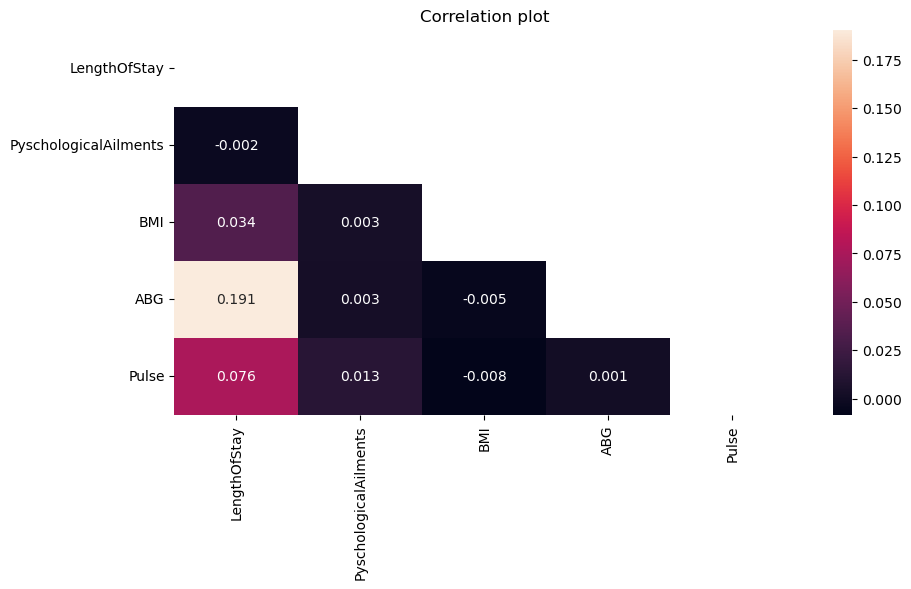

```python
plt.figure(figsize=(10,5))
corrvalue = HealthCareData.select_dtypes(exclude = 'object').corr()
matrix = np.triu(corrvalue)

sns.heatmap(corrvalue, annot=True, fmt=".3f",mask = matrix)
plt.title('Correlation plot')
plt.show()
```

###### Feature Engineering using hot-encoding

###### We have considered the categorical variables:

###### 'Gender','SecondaryDiagnosis','PyschologicalAilments',' SubstanceAbuseHistory','ReadmissionCount'

```python
df_encoded = pd.get_dummies(HealthCareData, columns = ['Gender','SecondaryDiagnosis',
                                                      'PyschologicalAilments','SubstanceAbuseHistory','ReadmissionCount'])

df_encoded.columns
```

```
Index(['LengthOfStay', 'BMI', 'ABG', 'Pulse', 'Gender_F', 'Gender_M',
       'SecondaryDiagnosis_0', 'SecondaryDiagnosis_1', 'SecondaryDiagnosis_2',
       'SecondaryDiagnosis_3', 'SecondaryDiagnosis_4', 'SecondaryDiagnosis_5',
       'SecondaryDiagnosis_6', 'SecondaryDiagnosis_7', 'SecondaryDiagnosis_8',
       'SecondaryDiagnosis_9', 'SecondaryDiagnosis_10',
       'PyschologicalAilments_False', 'PyschologicalAilments_True',
       'SubstanceAbuseHistory_None', 'SubstanceAbuseHistory_Some',
       'SubstanceAbuseHistory_Unknown', 'SubstanceAbuseHistory_Yes',
       'ReadmissionCount_1', 'ReadmissionCount_2', 'ReadmissionCount_3',
       'ReadmissionCount_4', 'ReadmissionCount_5'],
      dtype='object')
```

### Scaling and Fitting the Model

```python
target_column = 'LengthOfStay'
X = df_encoded.drop(['LengthOfStay'],axis = 1)
y = df_encoded['LengthOfStay']

X_train, X_test, y_train, y_test = train_test_split(X, y, train_size=0.75, test_size=0.25, random_state=100)

# Scaling is done after train test split to prevent data leakage
scaler = StandardScaler()
X_train_sc = scaler.fit_transform(X_train)
X_test_sc = scaler.transform(X_test)

model = LinearRegression()
model.fit(X_train_sc, y_train)

# Make predictions on the scaled test data
ypred_test = model.predict(X_test_sc)
ypred_train = model.predict(X_train_sc)
```

```python
mse = mean_squared_error(y_test, ypred_test)
r2 = r2_score(y_test, ypred_test)

# Print evaluation metrics
print(f"Mean Squared Error : {mse}")
print(f"R-squared : {r2}")
```

```
Mean Squared Error : 1.4693039155776864
R-squared : 0.8718324358071616
```

###### We have received an accuracy of 87.18%

```python
mse_train = mean_squared_error(y_train, ypred_train)
r2_train = r2_score(y_train, ypred_train)

print(f"Mean Squared Error : {mse_train}")
print(f"R-squared : {r2_train}")
```

```
Mean Squared Error : 1.5915167108363966
R-squared : 0.850890656649953
```

###### After fitting the model on the training data as well, we can see that the accuracy is 85.1%. The training model accuracy is slightly less than the testing model accuracy which indicates that the data is not overfitting. This is generally a desirable outcome because it suggests that the model is not simply memorizing the training data but is capable of generalizing to unseen data.

### Plotting a Regression Plot to Re-check if the data is Underfitting or Overfitting or neither

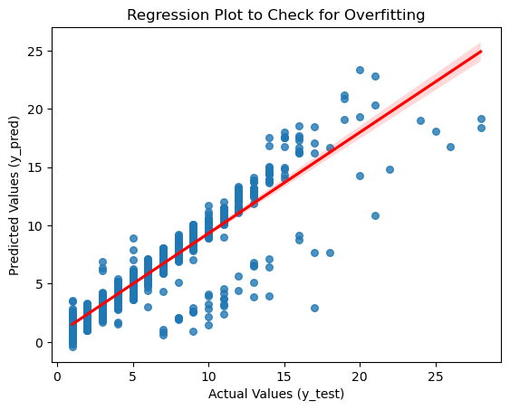

```python
sns.regplot(y = ypred_test, x = y_test, scatter_kws={'s': 30}, line_kws={'color': 'red'})
plt.title("Regression Plot to Check for Overfitting")
plt.xlabel("Actual Values (y_test)")
plt.ylabel("Predicted Values (y_pred)")
plt.show()
```

##### Creating a Scatter plot of Actual vs Predicted Values

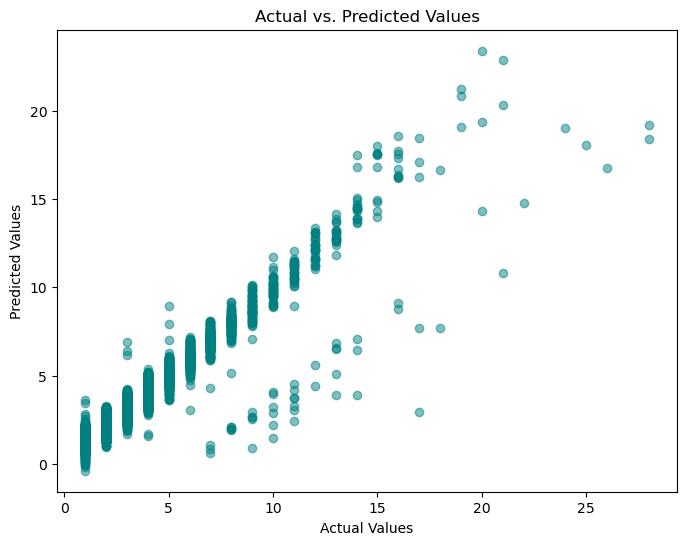

```python
plt.figure(figsize=(8, 6))
plt.scatter(y_test, ypred_test, alpha=0.5,color='teal')
plt.xlabel('Actual Values')
plt.ylabel('Predicted Values')
plt.title('Actual vs. Predicted Values')
```

###### Calculatting and creating a scatter plot of residuals

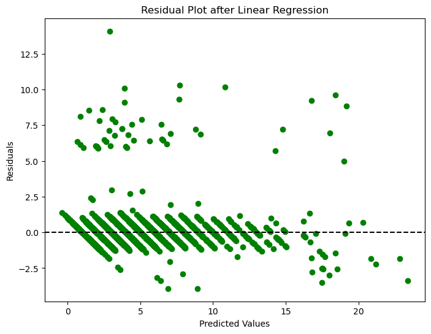

```python
residuals = y_test - ypred_test

# Plotting residuals
plt.figure(figsize=(8, 6))
plt.scatter(ypred_test, residuals, color='green')
plt.axhline(y=0, color='k', linestyle='--')
plt.xlabel('Predicted Values')
plt.ylabel('Residuals')
plt.title('Residual Plot after Linear Regression')
plt.show()
```

```python
HealthCareData.to_csv('HealthCareData.csv', index=False)
```